# team_project_3

- 태스크 정의
  - 워싱턴 D.C의 Bike Sharing 데이터를 활용해서 자전거 대여량을 예측한다
  - 데이터는 kaggle에서 구할 수 있다.(https://www.kaggle.com/c/bike-sharing-demand/)
- Dataset 로드

```python
import pandas as pd
import numpy as np

train = pd.read_csv('train.csv')
train.shape
```

```
(10886, 12)
```

```python
train.head()
```

|  | datetime | season | holiday | workingday | weather | temp | atemp | humidity | windspeed | casual | registered | count |
| --- | --- | --- | --- | --- | --- | --- | --- | --- | --- | --- | --- | --- |
| 0 | 2011-01-01 00:00:00 | 1 | 0 | 0 | 1 | 9.84 | 14.395 | 81 | 0.0 | 3 | 13 | 16 |
| 1 | 2011-01-01 01:00:00 | 1 | 0 | 0 | 1 | 9.02 | 13.635 | 80 | 0.0 | 8 | 32 | 40 |
| 2 | 2011-01-01 02:00:00 | 1 | 0 | 0 | 1 | 9.02 | 13.635 | 80 | 0.0 | 5 | 27 | 32 |
| 3 | 2011-01-01 03:00:00 | 1 | 0 | 0 | 1 | 9.84 | 14.395 | 75 | 0.0 | 3 | 10 | 13 |
| 4 | 2011-01-01 04:00:00 | 1 | 0 | 0 | 1 | 9.84 | 14.395 | 75 | 0.0 | 0 | 1 | 1 |

```python
test = pd.read_csv('test.csv')
test.head()
```

|  | datetime | season | holiday | workingday | weather | temp | atemp | humidity | windspeed |
| --- | --- | --- | --- | --- | --- | --- | --- | --- | --- |
| 0 | 2011-01-20 00:00:00 | 1 | 0 | 1 | 1 | 10.66 | 11.365 | 56 | 26.0027 |
| 1 | 2011-01-20 01:00:00 | 1 | 0 | 1 | 1 | 10.66 | 13.635 | 56 | 0.0000 |
| 2 | 2011-01-20 02:00:00 | 1 | 0 | 1 | 1 | 10.66 | 13.635 | 56 | 0.0000 |
| 3 | 2011-01-20 03:00:00 | 1 | 0 | 1 | 1 | 10.66 | 12.880 | 56 | 11.0014 |
| 4 | 2011-01-20 04:00:00 | 1 | 0 | 1 | 1 | 10.66 | 12.880 | 56 | 11.0014 |

- 데이터 전처리

```python
train["datetime"] = pd.to_datetime(train["datetime"])
train["datetime"].head()
```

```
0   2011-01-01 00:00:00
1   2011-01-01 01:00:00
2   2011-01-01 02:00:00
3   2011-01-01 03:00:00
4   2011-01-01 04:00:00
Name: datetime, dtype: datetime64[ns]
```

```python
test["datetime"] = pd.to_datetime(test["datetime"])
test["datetime"].head()
```

```
0   2011-01-20 00:00:00
1   2011-01-20 01:00:00
2   2011-01-20 02:00:00
3   2011-01-20 03:00:00
4   2011-01-20 04:00:00
Name: datetime, dtype: datetime64[ns]
```

- train 데이터에 연, 월, 일, 시, 분, 초를 나타내는 새로운 컬럼을 생성

```python
train["datetime-year"] = train["datetime"].dt.year
train["datetime-month"] = train["datetime"].dt.month
train["datetime-day"] = train["datetime"].dt.day
train["datetime-hour"] = train["datetime"].dt.hour
train["datetime-minute"] = train["datetime"].dt.minute
train["datetime-second"] = train["datetime"].dt.second

# dayofweek는 날짜에서 요일(월~일) 가져오는 기능
# 0(월), 1(화), 2(수), 3(목), 4(금), 5(토), 6(일)
train["datetime-dayofweek"] = train["datetime"].dt.dayofweek

train.head()
```

|  | datetime | season | holiday | workingday | weather | temp | atemp | humidity | windspeed | casual | registered | count | datetime-year | datetime-month | datetime-day | datetime-hour | datetime-minute | datetime-second | datetime-dayofweek |
| --- | --- | --- | --- | --- | --- | --- | --- | --- | --- | --- | --- | --- | --- | --- | --- | --- | --- | --- | --- |
| 0 | 2011-01-01 00:00:00 | 1 | 0 | 0 | 1 | 9.84 | 14.395 | 81 | 0.0 | 3 | 13 | 16 | 2011 | 1 | 1 | 0 | 0 | 0 | 5 |
| 1 | 2011-01-01 01:00:00 | 1 | 0 | 0 | 1 | 9.02 | 13.635 | 80 | 0.0 | 8 | 32 | 40 | 2011 | 1 | 1 | 1 | 0 | 0 | 5 |
| 2 | 2011-01-01 02:00:00 | 1 | 0 | 0 | 1 | 9.02 | 13.635 | 80 | 0.0 | 5 | 27 | 32 | 2011 | 1 | 1 | 2 | 0 | 0 | 5 |
| 3 | 2011-01-01 03:00:00 | 1 | 0 | 0 | 1 | 9.84 | 14.395 | 75 | 0.0 | 3 | 10 | 13 | 2011 | 1 | 1 | 3 | 0 | 0 | 5 |
| 4 | 2011-01-01 04:00:00 | 1 | 0 | 0 | 1 | 9.84 | 14.395 | 75 | 0.0 | 0 | 1 | 1 | 2011 | 1 | 1 | 4 | 0 | 0 | 5 |

```python
# datetime과 이와 연관된 나머지 일곱 개의 컬럼만 출력
train[["datetime", "datetime-year", "datetime-month", "datetime-day", "datetime-hour", "datetime-minute",
       "datetime-second", "datetime-dayofweek"]].head()
```

|  | datetime | datetime-year | datetime-month | datetime-day | datetime-hour | datetime-minute | datetime-second | datetime-dayofweek |
| --- | --- | --- | --- | --- | --- | --- | --- | --- |
| 0 | 2011-01-01 00:00:00 | 2011 | 1 | 1 | 0 | 0 | 0 | 5 |
| 1 | 2011-01-01 01:00:00 | 2011 | 1 | 1 | 1 | 0 | 0 | 5 |
| 2 | 2011-01-01 02:00:00 | 2011 | 1 | 1 | 2 | 0 | 0 | 5 |
| 3 | 2011-01-01 03:00:00 | 2011 | 1 | 1 | 3 | 0 | 0 | 5 |
| 4 | 2011-01-01 04:00:00 | 2011 | 1 | 1 | 4 | 0 | 0 | 5 |

```python
# datetime-dayofweek를 이해하기 편한 표현으로 변경 (Monday - Sunday)
train.loc[train["datetime-dayofweek"] == 0, "datetime-dayofweek(humanized)"] = "Monday"
train.loc[train["datetime-dayofweek"] == 1, "datetime-dayofweek(humanized)"] = "Tuesday"
train.loc[train["datetime-dayofweek"] == 2, "datetime-dayofweek(humanized)"] = "Wednesday"
train.loc[train["datetime-dayofweek"] == 3, "datetime-dayofweek(humanized)"] = "Thursday"
train.loc[train["datetime-dayofweek"] == 4, "datetime-dayofweek(humanized)"] = "Friday"
train.loc[train["datetime-dayofweek"] == 5, "datetime-dayofweek(humanized)"] = "Saturday"
train.loc[train["datetime-dayofweek"] == 6, "datetime-dayofweek(humanized)"] = "Sunday"

print(train.shape)

train[["datetime", "datetime-dayofweek", "datetime-dayofweek(humanized)"]].head()
```

```
(10886, 20)
```

|  | datetime | datetime-dayofweek | datetime-dayofweek(humanized) |
| --- | --- | --- | --- |
| 0 | 2011-01-01 00:00:00 | 5 | Saturday |
| 1 | 2011-01-01 01:00:00 | 5 | Saturday |
| 2 | 2011-01-01 02:00:00 | 5 | Saturday |
| 3 | 2011-01-01 03:00:00 | 5 | Saturday |
| 4 | 2011-01-01 04:00:00 | 5 | Saturday |

```python
# test 데이터 전처리
test["datetime-year"] = test["datetime"].dt.year
test["datetime-month"] = test["datetime"].dt.month
test["datetime-day"] = test["datetime"].dt.day
test["datetime-hour"] = test["datetime"].dt.hour
test["datetime-minute"] = test["datetime"].dt.minute
test["datetime-second"] = test["datetime"].dt.second

# dayofweek는 날짜에서 요일(월~일) 가져오는 기능
# 0(월), 1(화), 2(수), 3(목), 4(금), 5(토), 6(일)
test["datetime-dayofweek"] = test["datetime"].dt.dayofweek

test.loc[train["datetime-dayofweek"] == 0, "datetime-dayofweek(humanized)"] = "Monday"
test.loc[train["datetime-dayofweek"] == 1, "datetime-dayofweek(humanized)"] = "Tuesday"
test.loc[train["datetime-dayofweek"] == 2, "datetime-dayofweek(humanized)"] = "Wednesday"
test.loc[train["datetime-dayofweek"] == 3, "datetime-dayofweek(humanized)"] = "Thursday"
test.loc[train["datetime-dayofweek"] == 4, "datetime-dayofweek(humanized)"] = "Friday"
test.loc[train["datetime-dayofweek"] == 5, "datetime-dayofweek(humanized)"] = "Saturday"
test.loc[train["datetime-dayofweek"] == 6, "datetime-dayofweek(humanized)"] = "Sunday"

print(test.shape)

test[["datetime", "datetime-dayofweek", "datetime-dayofweek(humanized)"]].head()
```

```
(6493, 17)
```

|  | datetime | datetime-dayofweek | datetime-dayofweek(humanized) |
| --- | --- | --- | --- |
| 0 | 2011-01-20 00:00:00 | 3 | Saturday |
| 1 | 2011-01-20 01:00:00 | 3 | Saturday |
| 2 | 2011-01-20 02:00:00 | 3 | Saturday |
| 3 | 2011-01-20 03:00:00 | 3 | Saturday |
| 4 | 2011-01-20 04:00:00 | 3 | Saturday |

- 시각화

```python
%matplotlib inline

#데이터 시각화 패키지
import seaborn as sns

# 데이터 시각화 패키지
import matplotlib.pyplot as plt
```

- 연/월/일/시/분/초에 따른 자전거 대여량을 시각화

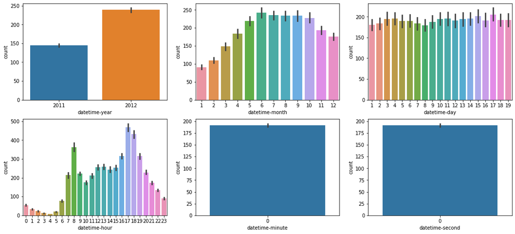

```python
# 2*3으로 총 6개의 시각화를 한 화면에 띄우기
figure, ((ax1, ax2, ax3), (ax4, ax5, ax6)) = plt.subplots(nrows=2, ncols=3)

# 시각화 전체 사이즈 설정(18*8)
figure.set_size_inches(18, 8)

# 연/월/일/시/분/초 별 자전거 대여량을 출력합니다.
sns.barplot(data=train, x="datetime-year", y="count", ax=ax1)
sns.barplot(data=train, x="datetime-month", y="count", ax=ax2)
sns.barplot(data=train, x="datetime-day", y="count", ax=ax3)
sns.barplot(data=train, x="datetime-hour", y="count", ax=ax4)
sns.barplot(data=train, x="datetime-minute", y="count", ax=ax5)
sns.barplot(data=train, x="datetime-second", y="count", ax=ax6)
```

- datetime-year : 2011년 보다 2012년에 count가 높은 것을 보아 대여량이 증가하였으므로 성장했다고 판단 가능
- datetime-month : 6월 ~ 10월 까지 대여량이 높으며, 12월 ~ 2월에는 대여량이 낮음을 확인
- datetime-day : 1일 부터 19일 까지의 데이터만 존재함을 확인, 확인 결과 test 데이터에 이후의 일자가 있음을 확인
- datetime-hour : 0시 부터 5시 까지는 count가 적음을 확인 할 수 있으며, 8시, 17시, 18시에 count가 높음을 확인
- datetime-minute, second : 데이터가 없음(기록되지 않음)을 확인
- 연-월을 붙여서 시각화 진행(datetime-year_month라는 새로운 컬럼을 만들어 진행)

```python
train["datetime-year(str)"] = train["datetime-year"].astype('str')
train["datetime-month(str)"] = train["datetime-month"].astype('str')

train["datetime-year_month"] = train["datetime-year(str)"] + "-" + train["datetime-month(str)"]

print(train.shape)

train[["datetime", "datetime-year_month"]].head()
```

```
(10886, 23)
```

|  | datetime | datetime-year_month |
| --- | --- | --- |
| 0 | 2011-01-01 00:00:00 | 2011-1 |
| 1 | 2011-01-01 01:00:00 | 2011-1 |
| 2 | 2011-01-01 02:00:00 | 2011-1 |
| 3 | 2011-01-01 03:00:00 | 2011-1 |
| 4 | 2011-01-01 04:00:00 | 2011-1 |

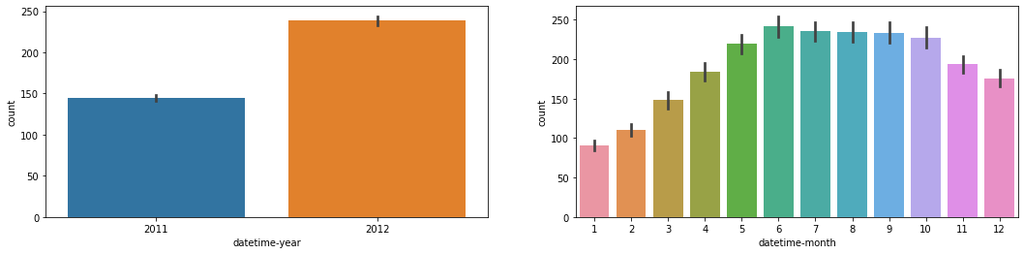

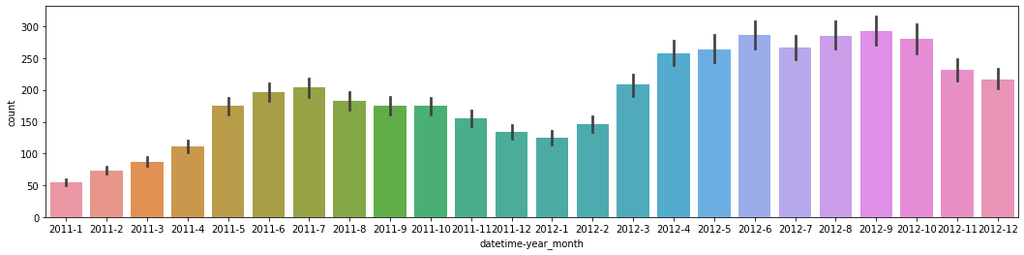

```python
# 1*2 로 시각화
figure, (ax1, ax2) = plt.subplots(nrows=1, ncols=2)

# 사이즈(18*4)
figure.set_size_inches(18, 4)

#  연, 월별 자전거 대출 시각화
sns.barplot(data=train, x="datetime-year", y="count", ax=ax1)
sns.barplot(data=train, x="datetime-month", y="count", ax=ax2)

# 1개로 시각화
figure, ax3 = plt.subplots(nrows=1, ncols=1)

# 사이즈(18, 4)
figure.set_size_inches(18, 4)

# 연_월을 붙인 자전거 대출 시각화
sns.barplot(data=train, x="datetime-year_month", y="count", ax=ax3)
```

- datetime-hour, workingday, datetime-dayofweek 분석

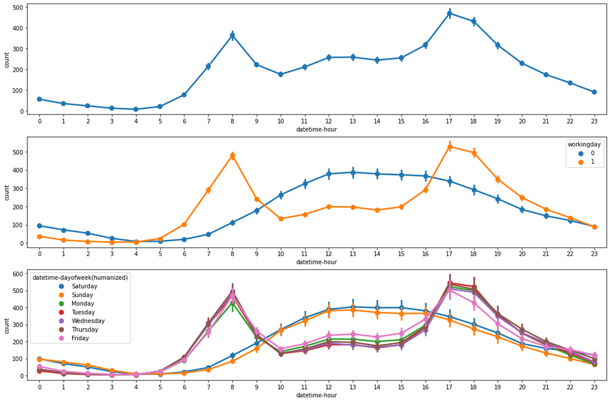

```python
figure, (ax1, ax2, ax3) = plt.subplots(nrows=3, ncols=1)
figure.set_size_inches(18, 12)

sns.pointplot(data=train, x="datetime-hour", y="count", ax=ax1)
sns.pointplot(data=train, x="datetime-hour", y="count", hue="workingday", ax=ax2)
sns.pointplot(data=train, x="datetime-hour", y="count", hue="datetime-dayofweek(humanized)", ax=ax3)
```

- Train

```python
#season(계절), holiday(공휴일), workingday(근무일), weather(날씨), temp(온도), atemp(체감온도)
#humidity(습도), windspeed(풍속), datetime-year(연도), datetime-hour(시간), datetime-dayofweek(요일)
feature_name = ["season", "holiday", "workingday", "weather", "temp", "atemp",
                "humidity", "windspeed", "datetime-year", "datetime-hour", "datetime-dayofweek"]
feature_name
```

```
['season',
 'holiday',
 'workingday',
 'weather',
 'temp',
 'atemp',
 'humidity',
 'windspeed',
 'datetime-year',
 'datetime-hour',
 'datetime-dayofweek']
```

```python
# count(자전거 대여량)을 label로 지정
label_name = "count"
label_name
```

```
'count'
```

```python
X_train = train[feature_name]
print(X_train.shape)
X_train.head()
```

```
(10886, 11)
```

|  | season | holiday | workingday | weather | temp | atemp | humidity | windspeed | datetime-year | datetime-hour | datetime-dayofweek |
| --- | --- | --- | --- | --- | --- | --- | --- | --- | --- | --- | --- |
| 0 | 1 | 0 | 0 | 1 | 9.84 | 14.395 | 81 | 0.0 | 2011 | 0 | 5 |
| 1 | 1 | 0 | 0 | 1 | 9.02 | 13.635 | 80 | 0.0 | 2011 | 1 | 5 |
| 2 | 1 | 0 | 0 | 1 | 9.02 | 13.635 | 80 | 0.0 | 2011 | 2 | 5 |
| 3 | 1 | 0 | 0 | 1 | 9.84 | 14.395 | 75 | 0.0 | 2011 | 3 | 5 |
| 4 | 1 | 0 | 0 | 1 | 9.84 | 14.395 | 75 | 0.0 | 2011 | 4 | 5 |

```python
X_test = test[feature_name]
print(X_test.shape)
X_test.head()
```

```
(6493, 11)
```

|  | season | holiday | workingday | weather | temp | atemp | humidity | windspeed | datetime-year | datetime-hour | datetime-dayofweek |
| --- | --- | --- | --- | --- | --- | --- | --- | --- | --- | --- | --- |
| 0 | 1 | 0 | 1 | 1 | 10.66 | 11.365 | 56 | 26.0027 | 2011 | 0 | 3 |
| 1 | 1 | 0 | 1 | 1 | 10.66 | 13.635 | 56 | 0.0000 | 2011 | 1 | 3 |
| 2 | 1 | 0 | 1 | 1 | 10.66 | 13.635 | 56 | 0.0000 | 2011 | 2 | 3 |
| 3 | 1 | 0 | 1 | 1 | 10.66 | 12.880 | 56 | 11.0014 | 2011 | 3 | 3 |
| 4 | 1 | 0 | 1 | 1 | 10.66 | 12.880 | 56 | 11.0014 | 2011 | 4 | 3 |

```python
y_train = train[label_name]
print(y_train.shape)
y_train.head()
```

```
(10886,)
```

```
0    16
1    40
2    32
3    13
4     1
Name: count, dtype: int64
```

- 랜덤 포레스트 사용

```python
from sklearn.ensemble import RandomForestRegressor

model = RandomForestRegressor()
model
```

```
RandomForestRegressor()
```

```python
# 랜덤 포레스트 모델 교차 검증
from sklearn.model_selection import cross_val_score

score = cross_val_score(model, X_train, y_train, cv=20).mean()
score
```

```
0.8778566948830697
```

```python
model.fit(X_train, y_train)
```

```
RandomForestRegressor()
```

```python
predictions = model.predict(X_test)
predictions
```

```
array([ 10.97      ,   4.93      ,   4.02      , ..., 100.29      ,
       101.73666667,  47.45      ])
```